# TFM: Riesgo de crédito - Análisis, desarrollo y código

Miguel García Sánchez

2023-07-14

# *INICIO DEL DESARROLLO DEL TRABAJO*

# 1. Introducción

El trabajo a desarrollar consiste en el análisis de un dataset relativo a datos de préstamos de entidades financieras, donde se quiere tratar de comprender cuales son las razones y características que llevan al llamado “default” o situación de impago, así como modelos que pueden ayudar a predecirlo y realizar un seguimiento sobre el mismo.

## 1.1. Desarrollo, programación y control de versiones

Se ha elegido para el desarrollo del trabajo el lenguaje de programación R (R version 4.2.2), cómo IDE de desarrollo RStudio (RStudio version 2022.12.0.353) y cómo herramienta de control de versiones GitHub (proyecto “/MDS_TFM” creado y vinculado al usuario Miguel_gs - “mgarciasanc2021”).

**Link del proyecto en GitHub:** https://github.com/mgarciasanc2021/MDS_TFM

## 1.2. Paquetes R

Los paquetes de R utilizados para el desarrollo del código han sido los siguientes:

```r
library(formatR)
library(readr)
library(ggplot2)
library(GGally)
library(dplyr)
library(tidyr)
library(missForest)
library(VIM)
library(formattable)
library(usmap)
library(cowplot)
library(corrplot)
library(MASS)
library(ggfortify)
library(nortest)
library(car)
library(lmtest)
library(PerformanceAnalytics)
library(Amelia)
library(ggthemes)
library(tidyverse)
library(tibble)
library(gridExtra)
library(factoextra)
library(caret)
library(ISLR)
library(rpart)
library(rpart.plot)
library(rattle)
library(tsne)
library(Rtsne)
library(class)
library(ada)
library(factoextra)
library(cluster)
library(useful)
library(mgcv)
library(xgboost)
library(randomForest)
library(kernlab)
library(pROC)
library(ggpubr)
library(ROCR)
```

# 2. Conjunto de datos

El conjunto de datos elegido para el desarrollo del trabajo es “Credit Risk Dataset”. Este dataset incluye información de clientes de banca retail y préstamos contratados por estos en diferentes instituciones financiera.

**Link del data set:** https://www.kaggle.com/datasets/laotse/credit-risk-dataset.

## 2.1. Carga de los datos

El conjunto de datos “Credit Risk Dataset” contiene 12 columnas y 32.581 filas y se obtiene en formato .CSV.

Inicialmente se han guardado los datos en un data frame llamado “fin_credrisk” y se ha realizado un estudio preliminar sobre su contenido utilizando la función head y count.

```r
fin_credrisk <- read_csv("financial_credit_risk.csv")
head(fin_credrisk)
```

```
## # A tibble: 6 × 12
##   person_age person_in…¹ perso…² perso…³ loan_…⁴ loan_…⁵ loan_…⁶ loan_…⁷ loan_…⁸
##        <dbl>       <dbl> <chr>     <dbl> <chr>   <chr>     <dbl>   <dbl>   <dbl>
## 1         22       59000 RENT        123 PERSON… D         35000   16.0        1
## 2         21        9600 OWN           5 EDUCAT… B          1000   11.1        0
## 3         25        9600 MORTGA…       1 MEDICAL C          5500   12.9        1
## 4         23       65500 RENT          4 MEDICAL C         35000   15.2        1
## 5         24       54400 RENT          8 MEDICAL C         35000   14.3        1
## 6         21        9900 OWN           2 VENTURE A          2500    7.14       1
## # … with 3 more variables: loan_percent_income <dbl>,
## #   cb_person_default_on_file <chr>, cb_person_cred_hist_length <dbl>, and
## #   abbreviated variable names ¹person_income, ²person_home_ownership,
## #   ³person_emp_length, ⁴loan_intent, ⁵loan_grade, ⁶loan_amnt, ⁷loan_int_rate,
## #   ⁸loan_status
```

```r
count(fin_credrisk)
```

```
## # A tibble: 1 × 1
##       n
##   <int>
## 1 32581
```

## 2.2. Definición de las variables

Empezando ya el análisis inicial del dataset que tenemos, se ve que las 12 variables que componen los datos pueden ser descritas como:

**Input variables o Variables de entrada/predictoras:**

- **person_age:** Edad de la persona que toma el crédito.
- **person_income:** Ingresos anuales en dólares de la persona que toma el crédito.
- **person_home_ownership:** Estado de la propiedad de la vivienda donde reside la persona que toma el crédito.
- **person_emp_length:** Periodo de tiempo en años desde que la persona que toma el crédito está en situación laboral activa.
- **loan_intent:** Uso del crédito concedido.
- **loan_grade:** Calidad crediticia del crédito concedido.
- **loan_amnt:** Cantidad en dólares de crédito concedido.
- **loan_int_rate:** Tipo de interés en porcentaje del crédito concedido.
- **loan_percent_income:** Porcentaje de lo que supone el préstamo sobre los ingresos anuales en dólares de la persona que toma el crédito.
- **cb_person_default_on_file:** Variable binaria que indica si la persona tomadora del crédito ha tenido antes una situación de impago o no.
- **cb_preson_cred_hist_length:** Duración en años del historial crediticio de la persona tomadora del crédito.

**Output variable o Variable de salida/respuesta/objetivo:**

- **loan_status:** Estado actual del crédito (suponiendo “1” como impagado o situación de default, y “0” no impagado)

Se analiza de forma preliminar estas variables utilizando la función summary.

```r
summary(fin_credrisk)
```

```
##    person_age     person_income     person_home_ownership person_emp_length
##  Min.   : 20.00   Min.   :   4000   Length:32581          Min.   :  0.00
##  1st Qu.: 23.00   1st Qu.:  38500   Class :character      1st Qu.:  2.00
##  Median : 26.00   Median :  55000   Mode  :character      Median :  4.00
##  Mean   : 27.73   Mean   :  66075                         Mean   :  4.79
##  3rd Qu.: 30.00   3rd Qu.:  79200                         3rd Qu.:  7.00
##  Max.   :144.00   Max.   :6000000                         Max.   :123.00
##                                                           NA's   :895
##  loan_intent         loan_grade          loan_amnt     loan_int_rate
##  Length:32581       Length:32581       Min.   :  500   Min.   : 5.42
##  Class :character   Class :character   1st Qu.: 5000   1st Qu.: 7.90
##  Mode  :character   Mode  :character   Median : 8000   Median :10.99
##                                        Mean   : 9589   Mean   :11.01
##                                        3rd Qu.:12200   3rd Qu.:13.47
##                                        Max.   :35000   Max.   :23.22
##                                                        NA's   :3116
##   loan_status     loan_percent_income cb_person_default_on_file
##  Min.   :0.0000   Min.   :0.0000      Length:32581
##  1st Qu.:0.0000   1st Qu.:0.0900      Class :character
##  Median :0.0000   Median :0.1500      Mode  :character
##  Mean   :0.2182   Mean   :0.1702
##  3rd Qu.:0.0000   3rd Qu.:0.2300
##  Max.   :1.0000   Max.   :0.8300
##
##  cb_person_cred_hist_length
##  Min.   : 2.000
##  1st Qu.: 3.000
##  Median : 4.000
##  Mean   : 5.804
##  3rd Qu.: 8.000
##  Max.   :30.000
##
```

Sacando estos datos, se ven algunos resultados importantes a comentar, que posteriormente deberan ser analizados en mayor detalle y tratados:

- La variable “person_age” tiene un valor máximo de 144 años.
- La variable “person_emp_length” tiene un valor máximo de 123 años.
- La variable “person_emp_length” tiene 895 registros con NAs.
- La variable “loan_interest_rate” tiene 3.116 registros con NAs.

## 2.3. Objetivo del análisis

El objetivo final del proyecto es conseguir llegar a un modelo que permita predecir el riesgo de impago o “default” que puede tener en cartera una institución financiera.

De esta forma, se optimiza la fase de concesión de créditos y seguimiento del riesgo de crédito, logrando diferenciar si estamos ante créditos que van a poder ser devueltos por el cliente, o por si el contrario se van a quedar potencialmente como impagados y es conveniente aplicar de forma anticipada medidas preventivas de cara a la posible fase de recuperación del crédito.

# *ANÁLISIS INICIAL, LIMPIEZA Y PARTICIONADO DE LOS DATOS*

# 3. Limpieza inicial del conjunto de datos

## 3.1. Cambio de nombres de las columnas

Se ha decidido no realizar un cambio en el nombre de las variables que aparecen en las columnas de los datos, ya que ya se sigue un patrón de nombre sin espaciones y así no habrá problemas con ello en el desarrollo del trabajo.

## 3.2. Cambio de tipo de variable de las columnas

Vemos que en el dataset existen variables de tipo numéricas (num - col_double()) y de tipo texto o cadena de caractéres (chr - col_character()).

```r
str(fin_credrisk)
```

```
## spc_tbl_ [32,581 × 12] (S3: spec_tbl_df/tbl_df/tbl/data.frame)
##  $ person_age                : num [1:32581] 22 21 25 23 24 21 26 24 24 21 ...
##  $ person_income             : num [1:32581] 59000 9600 9600 65500 54400 ...
##  $ person_home_ownership     : chr [1:32581] "RENT" "OWN" "MORTGAGE" "RENT" ...
##  $ person_emp_length         : num [1:32581] 123 5 1 4 8 2 8 5 8 6 ...
##  $ loan_intent               : chr [1:32581] "PERSONAL" "EDUCATION" "MEDICAL" "MEDICAL" ...
##  $ loan_grade                : chr [1:32581] "D" "B" "C" "C" ...
##  $ loan_amnt                 : num [1:32581] 35000 1000 5500 35000 35000 2500 35000 35000 35000 1600 ...
##  $ loan_int_rate             : num [1:32581] 16 11.1 12.9 15.2 14.3 ...
##  $ loan_status               : num [1:32581] 1 0 1 1 1 1 1 1 1 1 ...
##  $ loan_percent_income       : num [1:32581] 0.59 0.1 0.57 0.53 0.55 0.25 0.45 0.44 0.42 0.16 ...
##  $ cb_person_default_on_file : chr [1:32581] "Y" "N" "N" "N" ...
##  $ cb_person_cred_hist_length: num [1:32581] 3 2 3 2 4 2 3 4 2 3 ...
##  - attr(*, "spec")=
##   .. cols(
##   ..   person_age = col_double(),
##   ..   person_income = col_double(),
##   ..   person_home_ownership = col_character(),
##   ..   person_emp_length = col_double(),
##   ..   loan_intent = col_character(),
##   ..   loan_grade = col_character(),
##   ..   loan_amnt = col_double(),
##   ..   loan_int_rate = col_double(),
##   ..   loan_status = col_double(),
##   ..   loan_percent_income = col_double(),
##   ..   cb_person_default_on_file = col_character(),
##   ..   cb_person_cred_hist_length = col_double()
##   .. )
##  - attr(*, "problems")=<externalptr>
```

Se ha decidido por ello realizar cambio en el tipo de variable de las que son cadena de caracter y pasarlas a variables categóricas.

```r
fin_credrisk$person_home_ownership = as.factor(gsub("\\$", "",
    fin_credrisk$person_home_ownership))

fin_credrisk$loan_intent = as.factor(gsub("\\$", "", fin_credrisk$loan_intent))

fin_credrisk$loan_grade = as.factor(gsub("\\$", "", fin_credrisk$loan_grade))

fin_credrisk$cb_person_default_on_file = as.factor(gsub("\\$",
    "", fin_credrisk$cb_person_default_on_file))
```

Vemos que con el cambio tenemos en el dataset variables de tipo numéricas y categóricas o de tipo factor.

```r
str(fin_credrisk)
```

```
## spc_tbl_ [32,581 × 12] (S3: spec_tbl_df/tbl_df/tbl/data.frame)
##  $ person_age                : num [1:32581] 22 21 25 23 24 21 26 24 24 21 ...
##  $ person_income             : num [1:32581] 59000 9600 9600 65500 54400 ...
##  $ person_home_ownership     : Factor w/ 4 levels "MORTGAGE","OTHER",..: 4 3 1 4 4 3 4 4 4 3 ...
##  $ person_emp_length         : num [1:32581] 123 5 1 4 8 2 8 5 8 6 ...
##  $ loan_intent               : Factor w/ 6 levels "DEBTCONSOLIDATION",..: 5 2 4 4 4 6 2 4 5 6 ...
##  $ loan_grade                : Factor w/ 7 levels "A","B","C","D",..: 4 2 3 3 3 1 2 2 1 4 ...
##  $ loan_amnt                 : num [1:32581] 35000 1000 5500 35000 35000 2500 35000 35000 35000 1600 ...
##  $ loan_int_rate             : num [1:32581] 16 11.1 12.9 15.2 14.3 ...
##  $ loan_status               : num [1:32581] 1 0 1 1 1 1 1 1 1 1 ...
##  $ loan_percent_income       : num [1:32581] 0.59 0.1 0.57 0.53 0.55 0.25 0.45 0.44 0.42 0.16 ...
##  $ cb_person_default_on_file : Factor w/ 2 levels "N","Y": 2 1 1 1 2 1 1 1 1 1 ...
##  $ cb_person_cred_hist_length: num [1:32581] 3 2 3 2 4 2 3 4 2 3 ...
##  - attr(*, "spec")=
##   .. cols(
##   ..   person_age = col_double(),
##   ..   person_income = col_double(),
##   ..   person_home_ownership = col_character(),
##   ..   person_emp_length = col_double(),
##   ..   loan_intent = col_character(),
##   ..   loan_grade = col_character(),
##   ..   loan_amnt = col_double(),
##   ..   loan_int_rate = col_double(),
##   ..   loan_status = col_double(),
##   ..   loan_percent_income = col_double(),
##   ..   cb_person_default_on_file = col_character(),
##   ..   cb_person_cred_hist_length = col_double()
##   .. )
##  - attr(*, "problems")=<externalptr>
```

Cabría la posibilidad de tratar de transformar la variable “loan_status” en categórica en función de si estamos ante préstamos de crédito impagados (“default”) o no.

# 4. Análisis preliminar del conjunto de datos

## 4.1. Análisis de datos faltantes

Se pasa ahora a analizar en mayor profundidad lo detectado anteriomente respecto a datos faltantes en el dataset:

- La variable “person_emp_length” tiene 895 registros con NAs.
- La variable “loan_interest_rate” tiene 3.116 registros con NAs.

Haciendo uso de la librería VIM y de la librería Amelia, analizamos la estructura que tienen los datos faltantes dentro de nuestro data set para ver y entender como se distribuyen y a que variables afecta.

Se puede comprobar que la proporción de datos faltantes es de aproximadamente un 1%. Hay 895 observaciones con datos faltantes en la variable “person_emp_length” y 3.116 observaciones con datos faltantes en “loan_int_rate”.

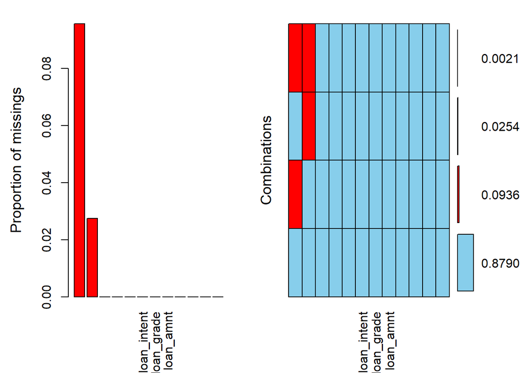

```
##
##  Variables sorted by number of missings:
##                    Variable      Count
##               loan_int_rate 0.09563856
##           person_emp_length 0.02747000
##                  person_age 0.00000000
##               person_income 0.00000000
##       person_home_ownership 0.00000000
##                 loan_intent 0.00000000
##                  loan_grade 0.00000000
##                   loan_amnt 0.00000000
##                 loan_status 0.00000000
##         loan_percent_income 0.00000000
##   cb_person_default_on_file 0.00000000
##  cb_person_cred_hist_length 0.00000000
```

```
##
##  Missings per variable:
##                    Variable Count
##                  person_age     0
##               person_income     0
##       person_home_ownership     0
##           person_emp_length   895
##                 loan_intent     0
##                  loan_grade     0
##                   loan_amnt     0
##               loan_int_rate  3116
##                 loan_status     0
##         loan_percent_income     0
##   cb_person_default_on_file     0
##  cb_person_cred_hist_length     0
##
##  Missings in combinations of variables:
##             Combinations Count    Percent
##  0:0:0:0:0:0:0:0:0:0:0:0 28638 87.8978546
##  0:0:0:0:0:0:0:1:0:0:0:0  3048  9.3551456
##  0:0:0:1:0:0:0:0:0:0:0:0   827  2.5382892
##  0:0:0:1:0:0:0:1:0:0:0:0    68  0.2087106
```

```r
summary(aggr(fin_credrisk, numbers = T, sortVar = T))
```

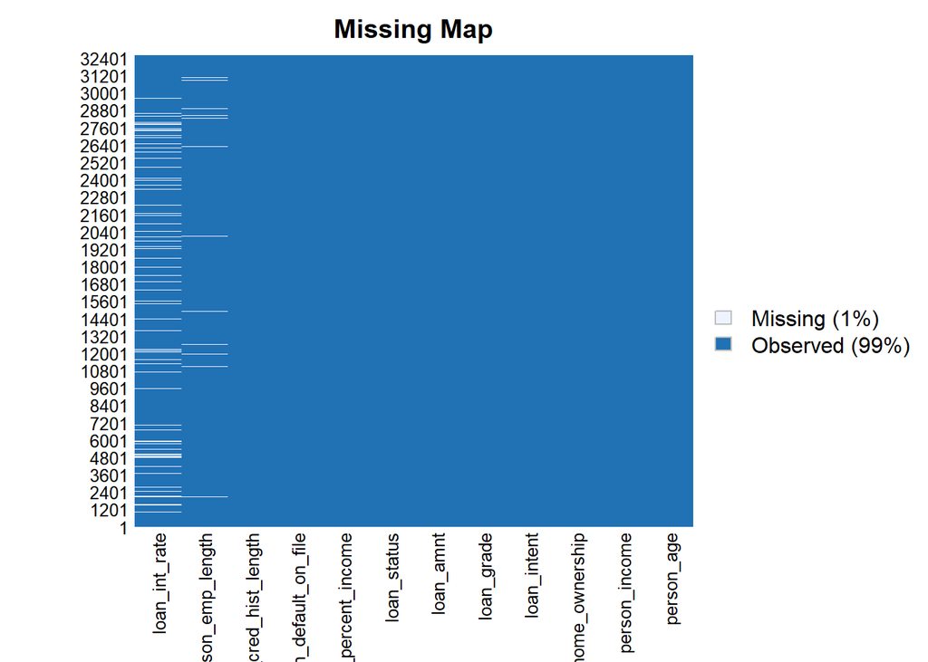

```r
missmap(fin_credrisk, main = "Missing Map")
```

### 4.1.2. Tratamiento e imputación de datos faltantes

Para realizar la imputación de datos faltantes en las columnas “person_emp_length” y “loan_int_rate”, se ha decidido reemplazar todos sus NAs según los valores medianos de las mismas variables a las que se referencian.

Con la función summary se comprueba que ya no hay más datos faltantes en el data set.

```r
fin_credrisk$person_emp_length[is.na(fin_credrisk$person_emp_length)] <- median(fin_credrisk$person_emp_length,
    na.rm = TRUE)
fin_credrisk$loan_int_rate[is.na(fin_credrisk$loan_int_rate)] <- median(fin_credrisk$loan_int_rate,
    na.rm = TRUE)

summary(fin_credrisk)
```

```
##    person_age     person_income     person_home_ownership person_emp_length
##  Min.   : 20.00   Min.   :   4000   MORTGAGE:13444        Min.   :  0.000
##  1st Qu.: 23.00   1st Qu.:  38500   OTHER   :  107        1st Qu.:  2.000
##  Median : 26.00   Median :  55000   OWN     : 2584        Median :  4.000
##  Mean   : 27.73   Mean   :  66075   RENT    :16446        Mean   :  4.768
##  3rd Qu.: 30.00   3rd Qu.:  79200                         3rd Qu.:  7.000
##  Max.   :144.00   Max.   :6000000                         Max.   :123.000
##
##             loan_intent   loan_grade   loan_amnt     loan_int_rate
##  DEBTCONSOLIDATION:5212   A:10777    Min.   :  500   Min.   : 5.42
##  EDUCATION        :6453   B:10451    1st Qu.: 5000   1st Qu.: 8.49
##  HOMEIMPROVEMENT  :3605   C: 6458    Median : 8000   Median :10.99
##  MEDICAL          :6071   D: 3626    Mean   : 9589   Mean   :11.01
##  PERSONAL         :5521   E:  964    3rd Qu.:12200   3rd Qu.:13.11
##  VENTURE          :5719   F:  241    Max.   :35000   Max.   :23.22
##                           G:   64
##   loan_status     loan_percent_income cb_person_default_on_file
##  Min.   :0.0000   Min.   :0.0000      N:26836
##  1st Qu.:0.0000   1st Qu.:0.0900      Y: 5745
##  Median :0.0000   Median :0.1500
##  Mean   :0.2182   Mean   :0.1702
##  3rd Qu.:0.0000   3rd Qu.:0.2300
##  Max.   :1.0000   Max.   :0.8300
##
##  cb_person_cred_hist_length
##  Min.   : 2.000
##  1st Qu.: 3.000
##  Median : 4.000
##  Mean   : 5.804
##  3rd Qu.: 8.000
##  Max.   :30.000
##
```

## 4.2. Análisis de datos atípico o outliers

Se pasa a realizar un análisis en mayor profundidad de lo detectado anteriomente respecto a datos atípico en el dataset:

- La variable “person_age” tiene un valor máximo de 144 años.
- La variable “person_emp_length” tiene un valor máximo de 123 años.

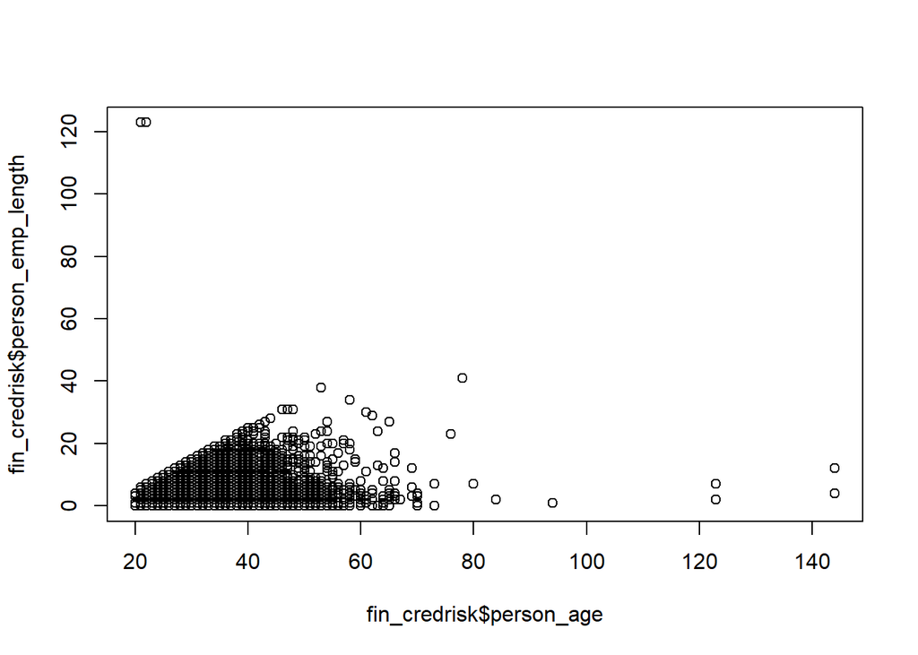

```r
plot(fin_credrisk$person_age, fin_credrisk$person_emp_length)
```

Vemos como hay algunos datos que si podemos considerar atípico. Hay 2 registros con un historial laboral de la persona contratante del préstamo (“person_emp_length”) de más de 120 años y 5 registros con una edad de la persona contratante del préstamo (“person_age”) superior a 120 años.

### 4.2.2. Tratamiento y eliminación de datos atípicos o outliers

Estos caso comentados son raros e ilógicos, y se opta finalmente por eliminarlos del dataset.

```r
fin_credrisk <- fin_credrisk %>%
    filter(person_age < 120) %>%
    filter(person_emp_length < 120)
```

Se muestra el resultado de como queda ahora el dataset con esta modificación. Ya no existen ni atípicos ni datos faltantes en el dataset. Ahora el dateset mantiene las 12 columnas, pero pasamos a tener 32.574 filas o registros.

```r
summary(fin_credrisk)
```

```
##    person_age    person_income     person_home_ownership person_emp_length
##  Min.   :20.00   Min.   :   4000   MORTGAGE:13441        Min.   : 0.000
##  1st Qu.:23.00   1st Qu.:  38500   OTHER   :  107        1st Qu.: 2.000
##  Median :26.00   Median :  55000   OWN     : 2584        Median : 4.000
##  Mean   :27.72   Mean   :  65879   RENT    :16442        Mean   : 4.761
##  3rd Qu.:30.00   3rd Qu.:  79200                         3rd Qu.: 7.000
##  Max.   :94.00   Max.   :2039784                         Max.   :41.000
##
##             loan_intent   loan_grade   loan_amnt     loan_int_rate
##  DEBTCONSOLIDATION:5212   A:10776    Min.   :  500   Min.   : 5.42
##  EDUCATION        :6451   B:10448    1st Qu.: 5000   1st Qu.: 8.49
##  HOMEIMPROVEMENT  :3605   C: 6456    Median : 8000   Median :10.99
##  MEDICAL          :6071   D: 3625    Mean   : 9588   Mean   :11.01
##  PERSONAL         :5519   E:  964    3rd Qu.:12200   3rd Qu.:13.11
##  VENTURE          :5716   F:  241    Max.   :35000   Max.   :23.22
##                           G:   64
##   loan_status     loan_percent_income cb_person_default_on_file
##  Min.   :0.0000   Min.   :0.0000      N:26830
##  1st Qu.:0.0000   1st Qu.:0.0900      Y: 5744
##  Median :0.0000   Median :0.1500
##  Mean   :0.2182   Mean   :0.1702
##  3rd Qu.:0.0000   3rd Qu.:0.2300
##  Max.   :1.0000   Max.   :0.8300
##
##  cb_person_cred_hist_length
##  Min.   : 2.000
##  1st Qu.: 3.000
##  Median : 4.000
##  Mean   : 5.804
##  3rd Qu.: 8.000
##  Max.   :30.000
##
```

```r
count(fin_credrisk)
```

```
## # A tibble: 1 × 1
##       n
##   <int>
## 1 32574
```

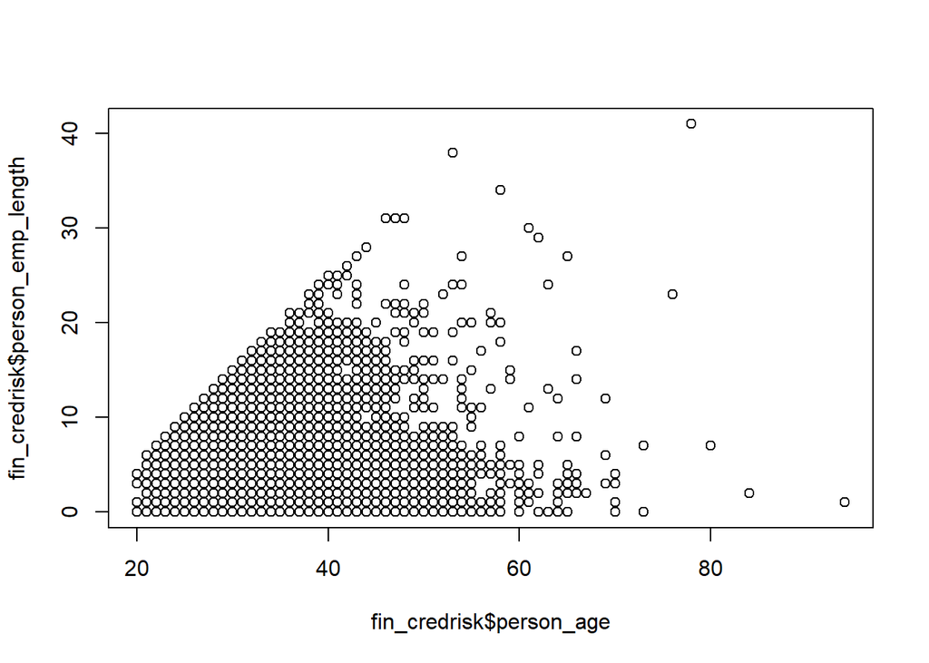

```r
plot(fin_credrisk$person_age, fin_credrisk$person_emp_length)
```

# 5. Partición del conjunto de datos: data set training y data set test

Una vez vista por encima la estructura general de los datos, se procede a dividir el conjunto de datos en dos para diferenciar los que se usarán de entrenamiento de los que usarán de test (viendo la cantidad de datos de los que se dispone, la distribución elegida ha sido: 20% test y 80% training). Además, se establece una semilla que guarde de forma permanente la división realizada para que la distribución de los datos sea siempre la misma y no sufra variaciones.

Se procede a guardar también la partición de datos de test para ser utilizada a futuro para la validación del modelo final. De aquí en adelante, se pasa a trabajar con la partición de training.

```r
set.seed(101)

sample <- sample.int(n = nrow(fin_credrisk), size = floor(0.8 *
    nrow(fin_credrisk)), replace = F)
fcr_train <- fin_credrisk[sample, ]
fcr_test <- fin_credrisk[-sample, ]
fcr_train
```

```
## # A tibble: 26,059 × 12
##    person_age person_i…¹ perso…² perso…³ loan_…⁴ loan_…⁵ loan_…⁶ loan_…⁷ loan_…⁸
##         <dbl>      <dbl> <fct>     <dbl> <fct>   <fct>     <dbl>   <dbl>   <dbl>
##  1         28      44000 RENT          2 MEDICAL C         10000   13.5        1
##  2         21      35000 OWN           5 VENTURE B          8000    9.91       0
##  3         25      96000 MORTGA…       6 HOMEIM… C         21000   14.6        0
##  4         22      67000 OWN           5 EDUCAT… D          7500   16.3        0
##  5         24      52800 RENT          8 PERSON… A          9000    7.49       0
##  6         27      50004 RENT         12 DEBTCO… B          3200   11.5        0
##  7         23      55488 RENT          4 MEDICAL D          5000   15.2        1
##  8         28      70000 RENT          2 DEBTCO… B          6000   10.4        0
##  9         22      55000 MORTGA…       6 PERSON… C         13000   13.8        0
## 10         26      43200 RENT          5 EDUCAT… C          3200   14.4        0
## # … with 26,049 more rows, 3 more variables: loan_percent_income <dbl>,
## #   cb_person_default_on_file <fct>, cb_person_cred_hist_length <dbl>, and
## #   abbreviated variable names ¹person_income, ²person_home_ownership,
## #   ³person_emp_length, ⁴loan_intent, ⁵loan_grade, ⁶loan_amnt, ⁷loan_int_rate,
## #   ⁸loan_status
```

```r
fcr_test
```

```
## # A tibble: 6,515 × 12
##    person_age person_i…¹ perso…² perso…³ loan_…⁴ loan_…⁵ loan_…⁶ loan_…⁷ loan_…⁸
##         <dbl>      <dbl> <fct>     <dbl> <fct>   <fct>     <dbl>   <dbl>   <dbl>
##  1         23      65500 RENT          4 MEDICAL C         35000   15.2        1
##  2         21       9900 OWN           2 VENTURE A          2500    7.14       1
##  3         23      95000 RENT          2 VENTURE A         35000    7.9        1
##  4         23     500000 MORTGA…       7 DEBTCO… B         30000   10.6        0
##  5         25     137000 RENT          9 PERSON… E         34800   16.8        0
##  6         24      10980 OWN           0 PERSON… A          1500    7.29       0
##  7         22      48000 RENT          1 EDUCAT… E         30000   18.4        1
##  8         24      12000 OWN           4 VENTURE B          2500   12.7        1
##  9         23     300000 OWN           1 EDUCAT… F         24250   19.4        0
## 10         23      78000 RENT          7 DEBTCO… F         30000   18.6        1
## # … with 6,505 more rows, 3 more variables: loan_percent_income <dbl>,
## #   cb_person_default_on_file <fct>, cb_person_cred_hist_length <dbl>, and
## #   abbreviated variable names ¹person_income, ²person_home_ownership,
## #   ³person_emp_length, ⁴loan_intent, ⁵loan_grade, ⁶loan_amnt, ⁷loan_int_rate,
## #   ⁸loan_status
```

# *ANÁLISIS EN PROFUNDIDAD DE LOS DATOS*

# 6. EDA - Análisis exploratorio de datos

## 6.1. Análisis de la distribución de las variables

Se analizan como se distribuyen las diferentes variables de entrada del dataset:

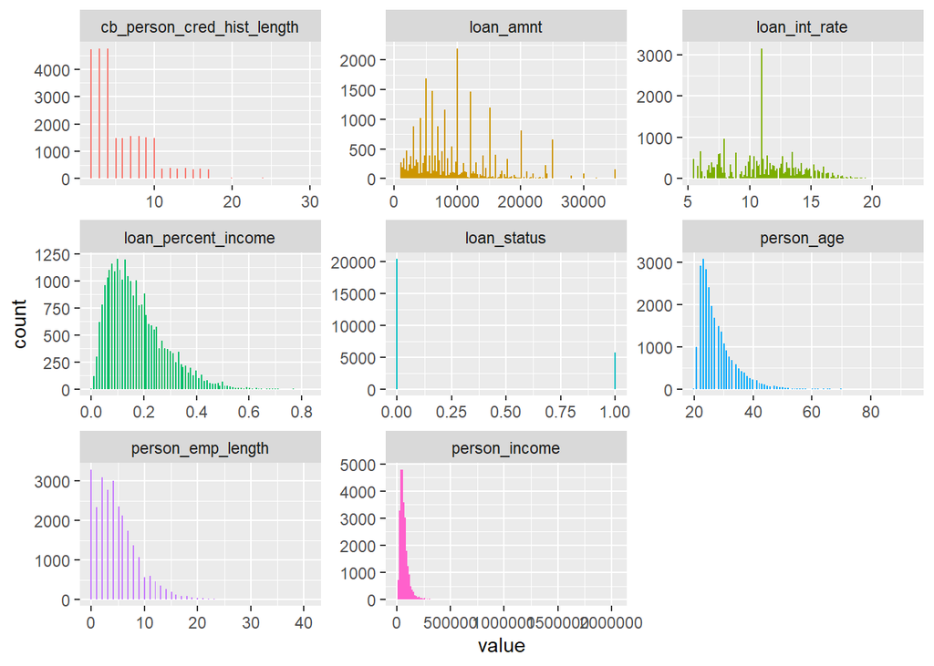

```r
fcr_train %>%
    keep(is.numeric) %>%
    gather() %>%
    ggplot(aes(value, fill = key)) + facet_wrap(~key, scales = "free") +
    geom_histogram(bins = sqrt(nrow(fcr_train))) + theme(legend.position = "none")
```

- **Variables numéricas relativas a la persona**

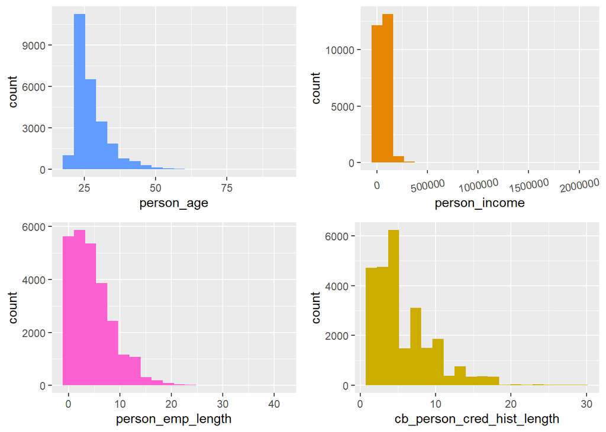

```r
ga <- fcr_train %>%
    ggplot(aes(x = person_age)) + geom_histogram(bins = 20, fill = "#619CFF")

gb <- fcr_train %>%
    ggplot(aes(x = person_income)) + geom_histogram(bins = 20,
    fill = "#E58700") + theme(axis.text.x = element_text(angle = 10,
    hjust = 0.5, vjust = 0.5))

gd <- fcr_train %>%
    ggplot(aes(x = person_emp_length)) + geom_histogram(bins = 20,
    fill = "#FD61D1")

gl <- fcr_train %>%
    ggplot(aes(x = cb_person_cred_hist_length)) + geom_histogram(bins = 20,
    fill = "#CDAD00")

grid.arrange(ga, gb, gd, gl)
```

- **Variables numéricas relativas al préstamo**

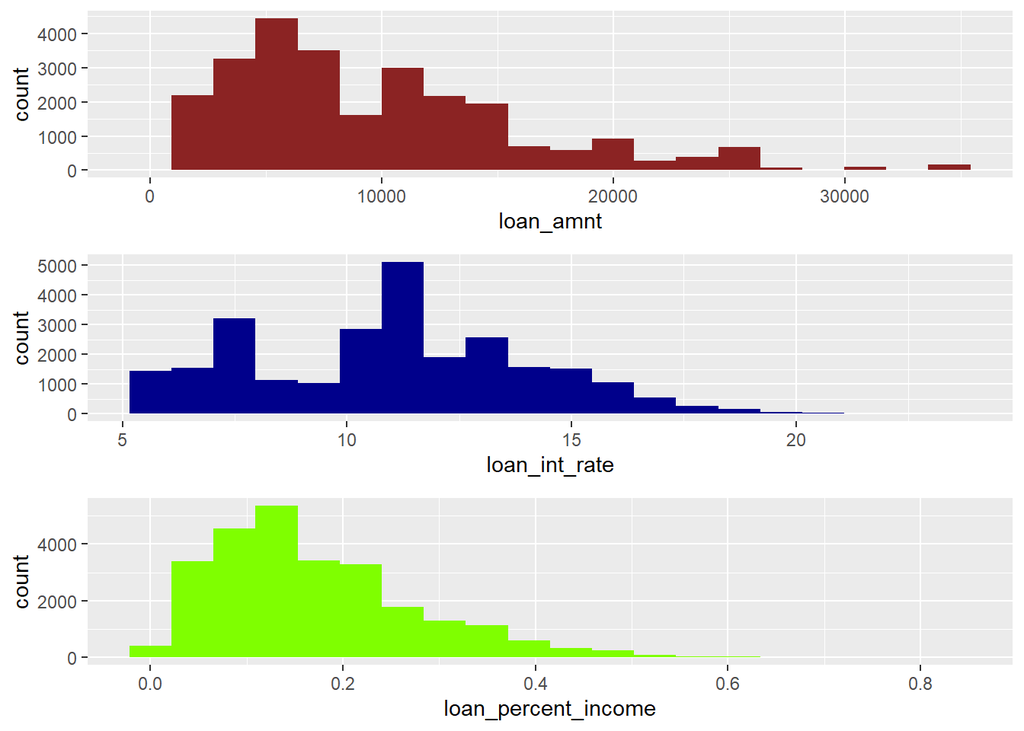

```r
gg <- fcr_train %>%
    ggplot(aes(x = loan_amnt)) + geom_histogram(bins = 20, fill = "#8B2323")

gh <- fcr_train %>%
    ggplot(aes(x = loan_int_rate)) + geom_histogram(bins = 20,
    fill = "#00008B")

gj <- fcr_train %>%
    ggplot(aes(x = loan_percent_income)) + geom_histogram(bins = 20,
    fill = "#7FFF00")

grid.arrange(gg, gh, gj)
```

- **Variables categóricas relativas a la persona**

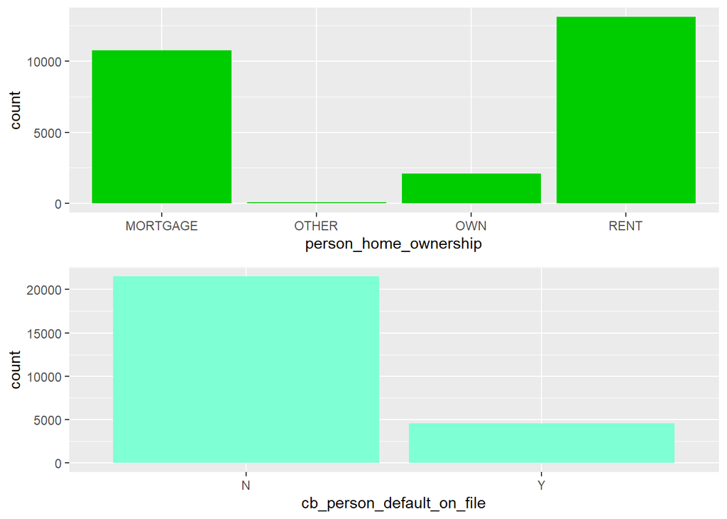

```r
gc <- fcr_train %>%
    ggplot(aes(x = person_home_ownership)) + geom_histogram(bins = 20,
    fill = "#00CD00", stat = "count")

gk <- fcr_train %>%
    ggplot(aes(x = cb_person_default_on_file)) + geom_histogram(bins = 20,
    fill = "#7FFFD4", stat = "count")

grid.arrange(gc, gk)
```

- **Variables categóricas relativas al préstamo**

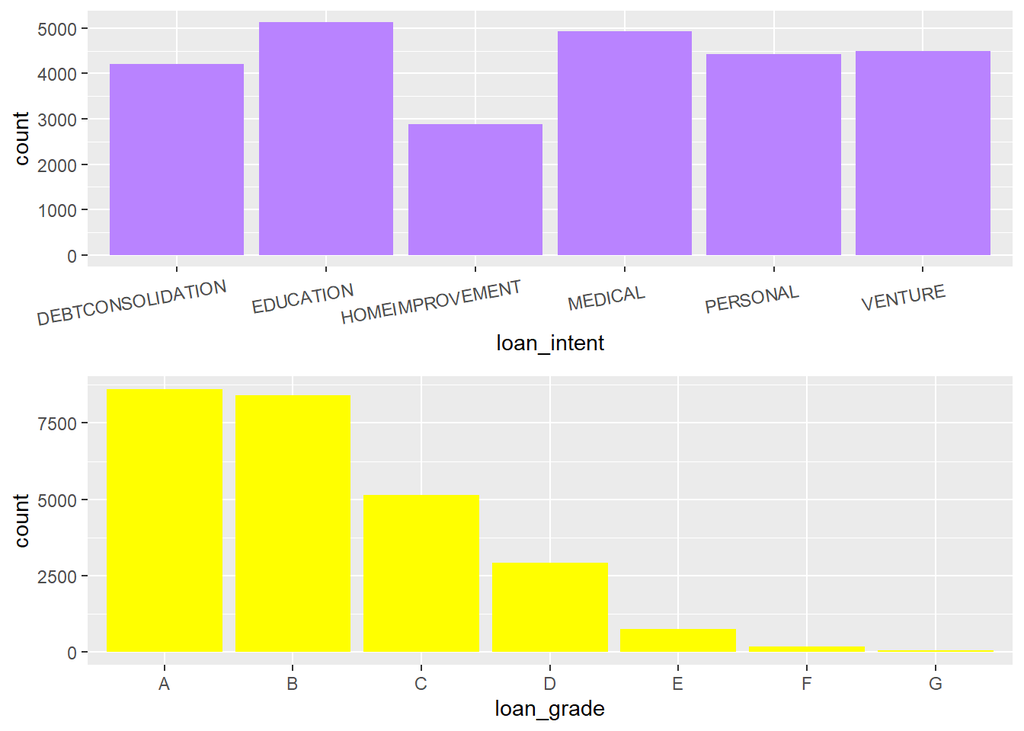

```r
ge <- fcr_train %>%
    ggplot(aes(x = loan_intent)) + geom_histogram(bins = 20,
    fill = "#B983FF", stat = "count") + theme(axis.text.x = element_text(angle = 10,
    hjust = 0.75, vjust = 0.75))

gf <- fcr_train %>%
    ggplot(aes(x = loan_grade)) + geom_histogram(bins = 20, fill = "#FFFF00",
    stat = "count")

grid.arrange(ge, gf)
```

Se analiza como se distribuye la variable objetivo del dataset:

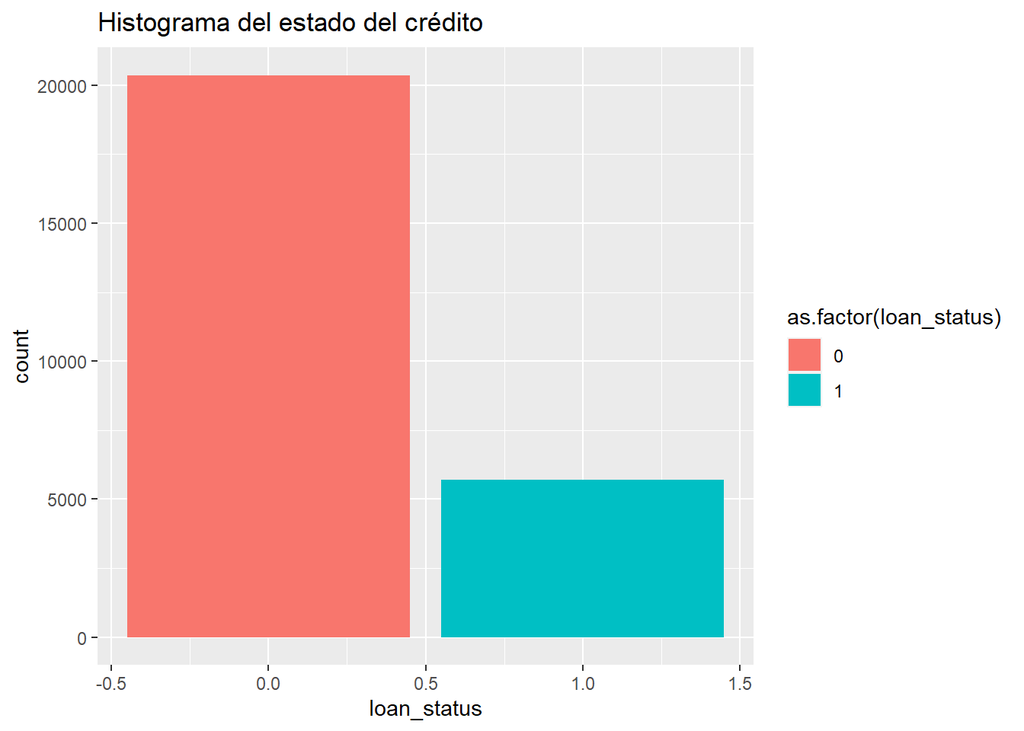

```r
ggplot(data = fcr_train) + geom_bar(mapping = aes(x = loan_status,
    fill = as.factor(loan_status))) + labs(title = "Histograma del estado del crédito")
```

```r
table(fcr_train$loan_status)
```

```
##
##     0     1
## 20365  5694
```

```r
prop.table(table(fcr_train$loan_status))
```

```
##
##         0         1
## 0.7814958 0.2185042
```

El 78.15% de los registros en el dataset de train (20.365 registros) tiene valor 0 correspondiente a créditos que no han entrado en default, y el 21.85% (5.694 registros) tienen valor 1 correspondiente a créditos que por el contrario si han sido impagados.

## 6.2. Boxplot - análisis de la variables de relevancia y de los atípicos observados

Se analiza si las variables tienen valores atípicos, cuales son sus valores medios y se ven sus intervalos de confianza, a través de gráficos de tipo Boxplot.

- **Boxplot variable person_age**

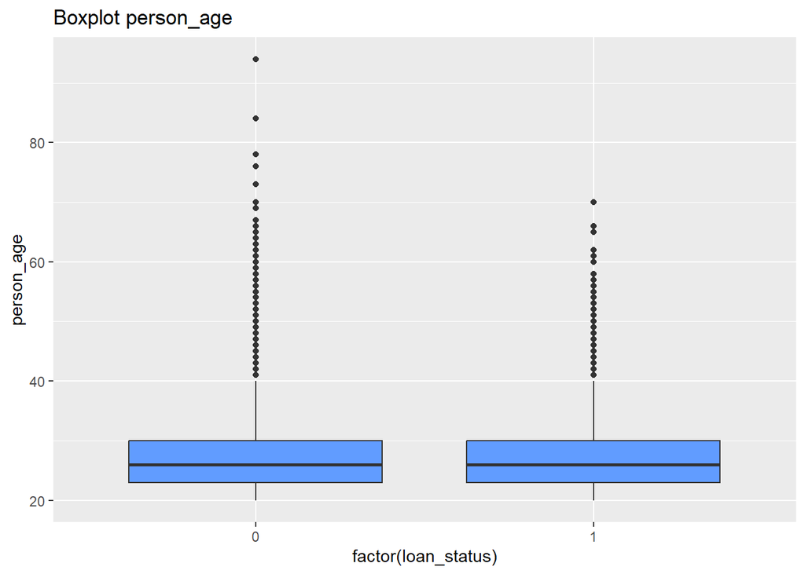

```r
BoxPlot_person_age <- ggplot(fcr_train, aes(x = factor(loan_status),
    y = person_age)) + geom_boxplot() + geom_boxplot(fill = "#619CFF") +
    ggtitle("Boxplot person_age")
BoxPlot_person_age
```

Se aprecia como la variable “person_age” relativa a la edad del contratante del préstamo se mantiene bastante igual en los casos donde hay default o no hay default.

- **Boxplot variable person_income**

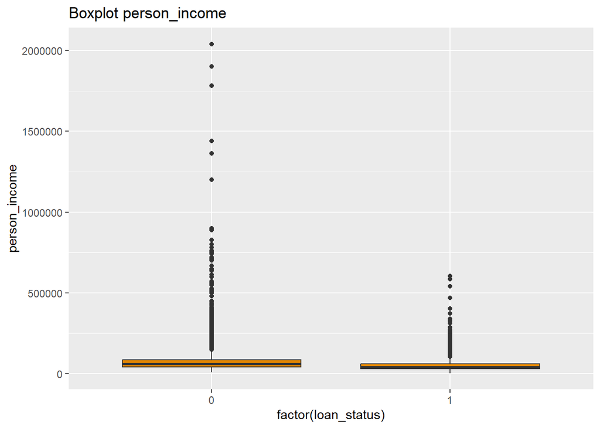

```r
BoxPlot_person_income <- ggplot(fcr_train, aes(x = factor(loan_status),
    y = person_income)) + geom_boxplot() + geom_boxplot(fill = "#E58700") +
    ggtitle("Boxplot person_income")
BoxPlot_person_income
```

Se aprecia ligeramente como la variable “person_income” relativa a los ingresos anuales del contratante del préstamo, es inferior en media en los casos donde se da el impago del crédito.

- **Boxplot variable person_emp_length**

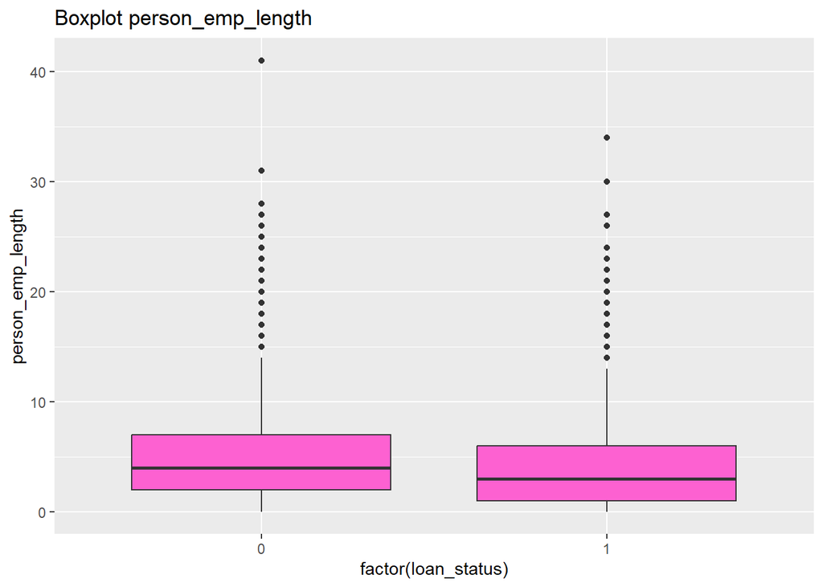

```r
BoxPlot_person_emp_length <- ggplot(fcr_train, aes(x = factor(loan_status),
    y = person_emp_length)) + geom_boxplot() + geom_boxplot(fill = "#FD61D1") +
    ggtitle("Boxplot person_emp_length")
BoxPlot_person_emp_length
```

Se aprecia ligeramente como la variable “person_emp_length” relativa al periodo de tiempo en años desde que la persona que toma el crédito está en situación laboral activa, es inferior en media en los casos donde se da el impago del crédito.

- **Boxplot variable cb_person_cred_hist_length**

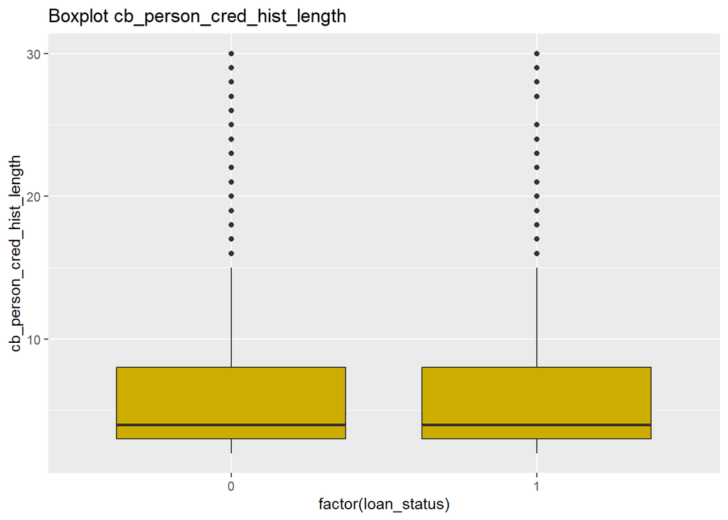

```r
BoxPlot_cb_person_cred_hist_length <- ggplot(fcr_train, aes(x = factor(loan_status),
    y = cb_person_cred_hist_length)) + geom_boxplot() + geom_boxplot(fill = "#CDAD00") +
    ggtitle("Boxplot cb_person_cred_hist_length")
BoxPlot_cb_person_cred_hist_length
```

Se aprecia como la variable “person_cred_hist_length” relativa a la duración en años del historial crediticio de la persona tomadora del crédito, se mantiene bastante igual en los casos donde hay default o no hay default.

- **Boxplot variable loan_amnt**

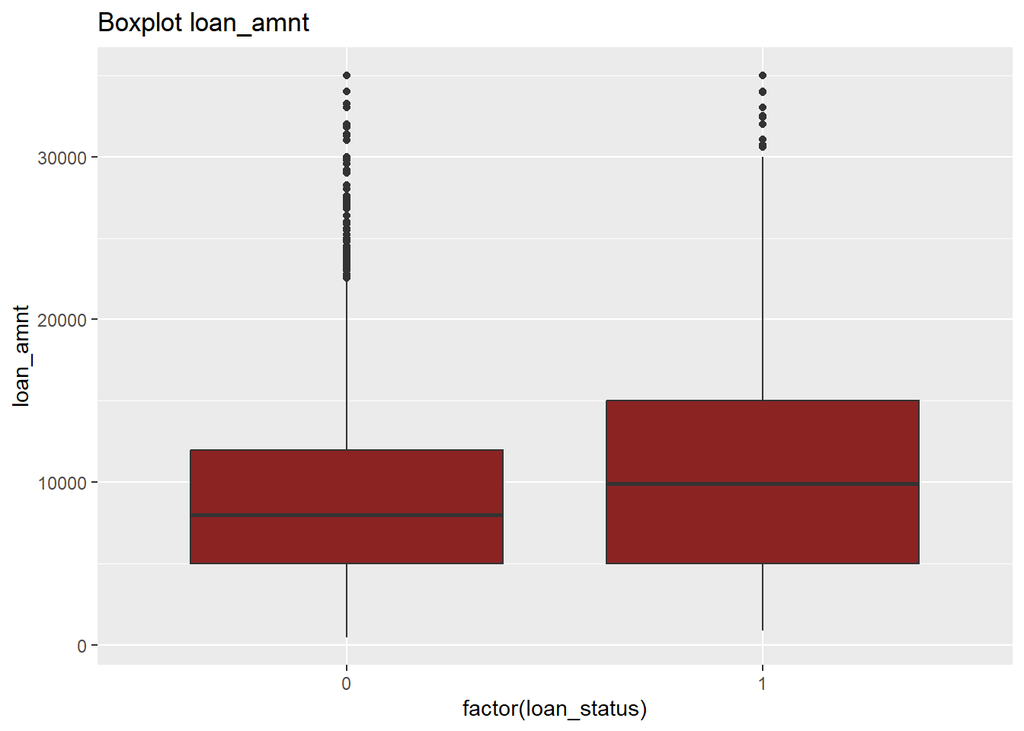

```r
BoxPlot_loan_amnt <- ggplot(fcr_train, aes(x = factor(loan_status),
    y = loan_amnt)) + geom_boxplot() + geom_boxplot(fill = "#8B2323") +
    ggtitle("Boxplot loan_amnt")
BoxPlot_loan_amnt
```

Se aprecia como la variable “loan_amount” relativa a la cantidad en dólares de crédito concedido, es superior en media en los casos donde se da el impago del crédito.

- **Boxplot variable loan_int_rate**

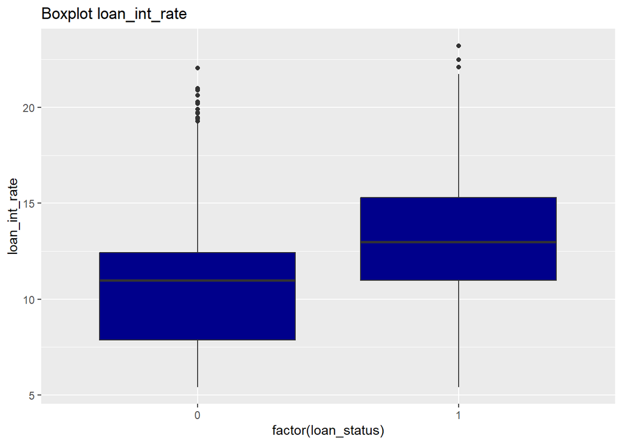

```r
BoxPlot_loan_int_rate <- ggplot(fcr_train, aes(x = factor(loan_status),
    y = loan_int_rate)) + geom_boxplot() + geom_boxplot(fill = "#00008B") +
    ggtitle("Boxplot loan_int_rate")
BoxPlot_loan_int_rate
```

Se aprecia como la variable “loan_int_rate” relativa al tipo de interés en porcentaje del crédito concedido, es superior en media en los casos donde se da el impago del crédito.

- **Boxplot variable loan_percent_income**

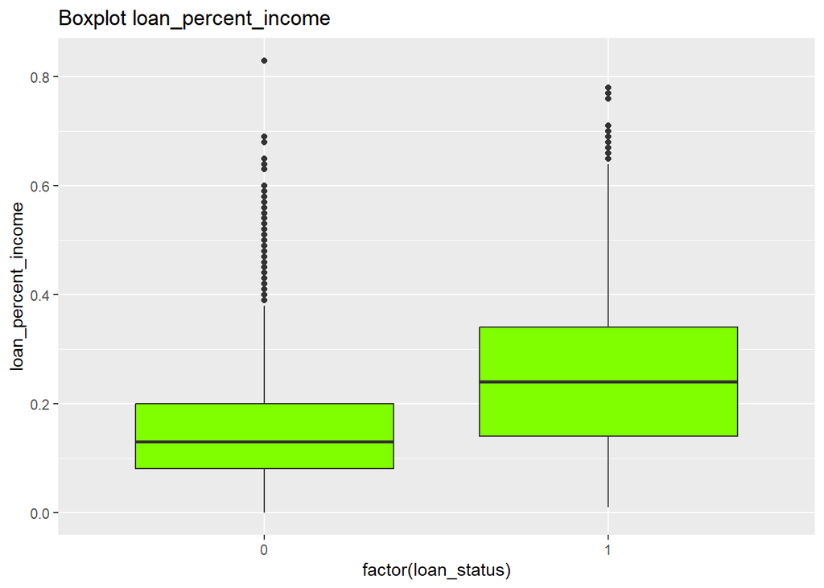

```r
BoxPlot_loan_percent_income <- ggplot(fcr_train, aes(x = factor(loan_status),
    y = loan_percent_income)) + geom_boxplot() + geom_boxplot(fill = "#7FFF00") +
    ggtitle("Boxplot loan_percent_income")
BoxPlot_loan_percent_income
```

Se aprecia como la variable “loan_percent_income” relativa al porcentaje de lo que supone el préstamo sobre los ingresos anuales en dólares de la persona que toma el crédito, es superior en media en los casos donde se da el impago del crédito.

Como conclusión lógica de todo esto, normalmente el la situación de impago es más frecuente en personas con ingresos más bajos, menor número de años de actividad laboral y con préstamos de cantidades más altas y con tipos de interés más elevados.

## 6.3. Correlación entre variables

Continuando con en análisis de las distintas variables del dataset y el estudio de como se relacionan entre si, se quiere analizar de forma global como se correlacionan las variables numéricas que nos pueden llegar a servir para el modelo de predicción objetivo.

### 6.3.1. Análisis de la correlación global del conjunto de variables

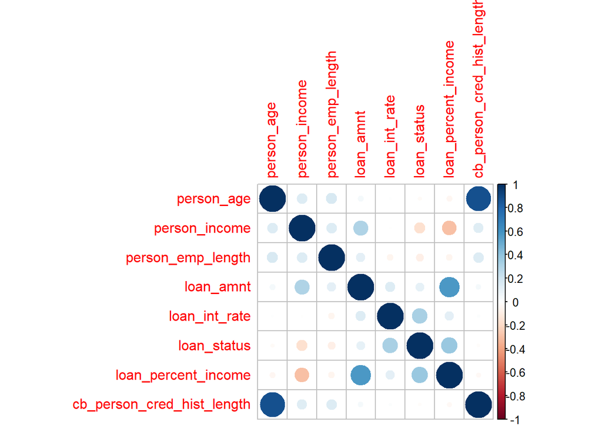

```r
corrplot(cor(fcr_train %>%
    mutate(loan_status = as.numeric(loan_status)) %>%
    keep(is.numeric)))
```

```r
res <- cor(fcr_train %>%
    mutate(loan_status = as.numeric(loan_status)) %>%
    keep(is.numeric))
round(res, 2)
```

```
##                            person_age person_income person_emp_length loan_amnt
## person_age                       1.00          0.15              0.17      0.05
## person_income                    0.15          1.00              0.15      0.31
## person_emp_length                0.17          0.15              1.00      0.11
## loan_amnt                        0.05          0.31              0.11      1.00
## loan_int_rate                    0.01         -0.01             -0.05      0.14
## loan_status                     -0.02         -0.17             -0.09      0.11
## loan_percent_income             -0.05         -0.29             -0.06      0.57
## cb_person_cred_hist_length       0.88          0.13              0.15      0.04
##                            loan_int_rate loan_status loan_percent_income
## person_age                          0.01       -0.02               -0.05
## person_income                      -0.01       -0.17               -0.29
## person_emp_length                  -0.05       -0.09               -0.06
## loan_amnt                           0.14        0.11                0.57
## loan_int_rate                       1.00        0.32                0.12
## loan_status                         0.32        1.00                0.38
## loan_percent_income                 0.12        0.38                1.00
## cb_person_cred_hist_length          0.02       -0.02               -0.04
##                            cb_person_cred_hist_length
## person_age                                       0.88
## person_income                                    0.13
## person_emp_length                                0.15
## loan_amnt                                        0.04
## loan_int_rate                                    0.02
## loan_status                                     -0.02
## loan_percent_income                             -0.04
## cb_person_cred_hist_length                       1.00
```

Se aprecia que las variables que más estan correlacionadas con la variable respuesta “loan_status” son: “person_income”, “loan_amnt”, “loan_int_rate” y “loan_percent_income”.

### 6.3.2. Análisis de la correlación bivariante

Se pasa a realizar un análisis bivariante para ver que variables están más correlacionadas, positiva o negativamente, entre si.

- **Correlación: person_age y cb_person_cred_hist_length:**

```r
cor(x = fcr_train$person_age, y = fcr_train$cb_person_cred_hist_length)
```

```
## [1] 0.8775082
```

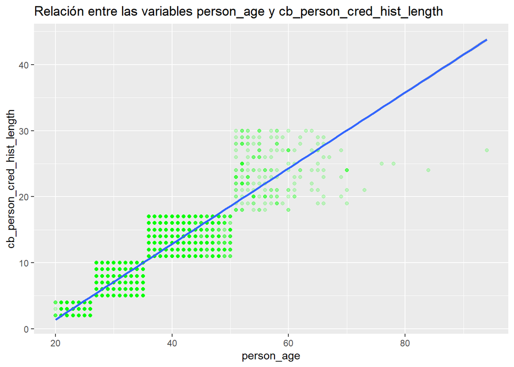

```r
fcr_train %>%
    ggplot(aes(person_age, cb_person_cred_hist_length)) + geom_point(alpha = 0.2,
    colour = "green") + geom_smooth(formula = "y ~ x", method = "lm") +
    labs(title = "Relación entre las variables person_age y cb_person_cred_hist_length",
        x = "person_age", y = "cb_person_cred_hist_length")
```

- **Correlación: loan_amnt y person_income:**

```r
cor(x = fcr_train$loan_amnt, y = fcr_train$person_income)
```

```
## [1] 0.3084375
```

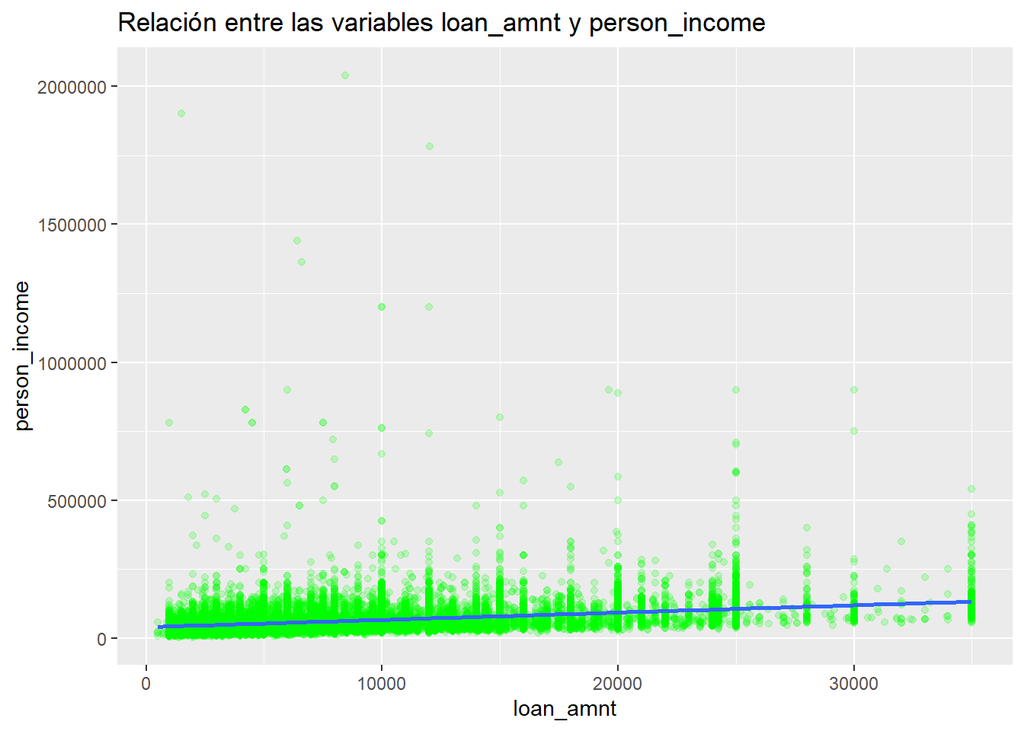

```r
fcr_train %>%
    ggplot(aes(loan_amnt, person_income)) + geom_point(alpha = 0.2,
    colour = "green") + geom_smooth(formula = "y ~ x", method = "lm") +
    labs(title = "Relación entre las variables loan_amnt y person_income",
        x = "loan_amnt", y = "person_income")
```

- **Correlación: loan_percent_income y person_income:**

```r
cor(x = fcr_train$loan_percent_income, y = fcr_train$person_income)
```

```
## [1] -0.2900526
```

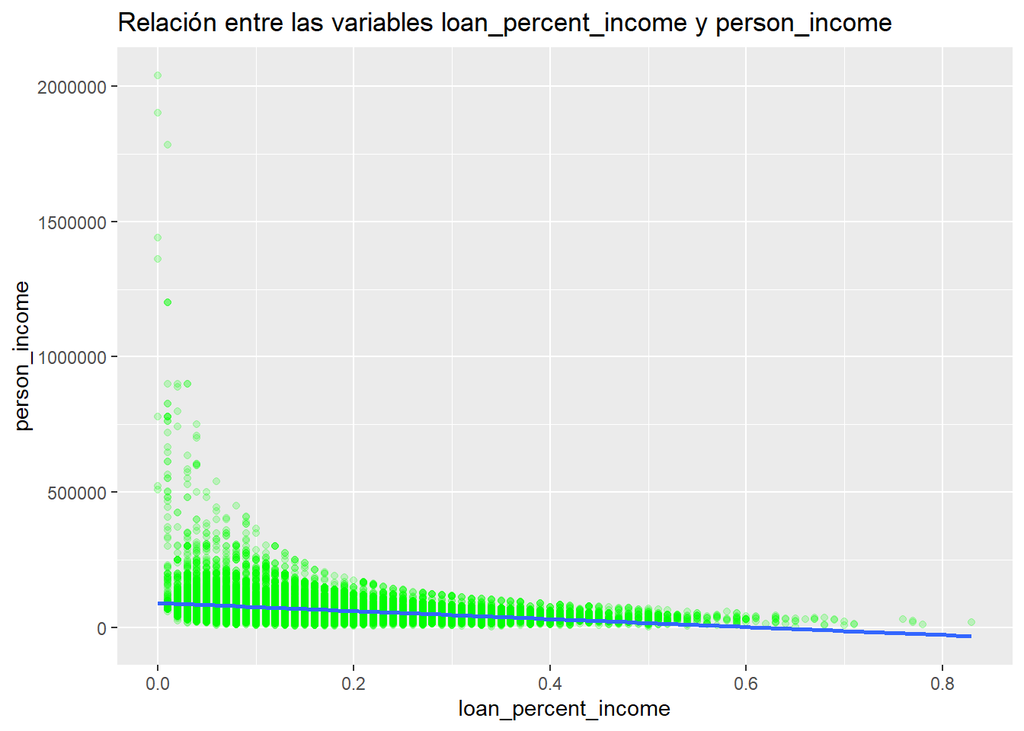

```r
fcr_train %>%
    ggplot(aes(loan_percent_income, person_income)) + geom_point(alpha = 0.2,
    colour = "green") + geom_smooth(formula = "y ~ x", method = "lm") +
    labs(title = "Relación entre las variables loan_percent_income y person_income",
        x = "loan_percent_income", y = "person_income")
```

- **Correlación: loan_percent_income y loan_amnt:**

```r
cor(x = fcr_train$loan_percent_income, y = fcr_train$loan_amnt)
```

```
## [1] 0.5707228
```

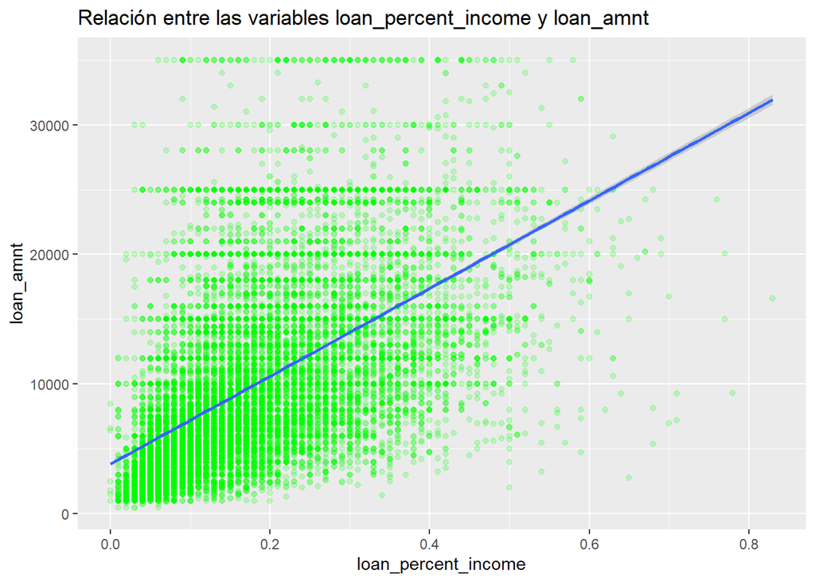

```r
fcr_train %>%
    ggplot(aes(loan_percent_income, loan_amnt)) + geom_point(alpha = 0.2,
    colour = "green") + geom_smooth(formula = "y ~ x", method = "lm") +
    labs(title = "Relación entre las variables loan_percent_income y loan_amnt",
        x = "loan_percent_income", y = "loan_amnt")
```

- **Correlación: loan_status y loan_int_rate:**

```r
cor(x = fcr_train$loan_status, y = fcr_train$loan_int_rate)
```

```
## [1] 0.3211891
```

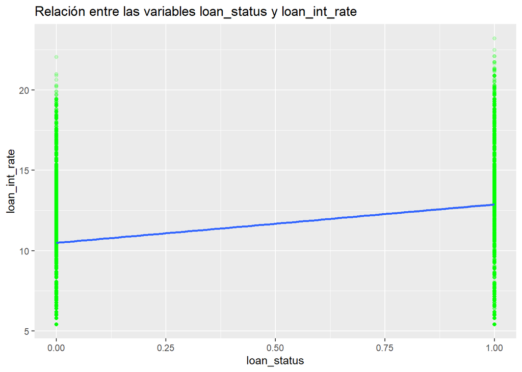

```r
fcr_train %>%
    ggplot(aes(loan_status, loan_int_rate)) + geom_point(alpha = 0.2,
    colour = "green") + geom_smooth(formula = "y ~ x", method = "lm") +
    labs(title = "Relación entre las variables loan_status y loan_int_rate",
        x = "loan_status", y = "loan_int_rate")
```

- **Correlación: loan_status y loan_percent_income:**

```r
cor(x = fcr_train$loan_status, y = fcr_train$loan_percent_income)
```

```
## [1] 0.3796514
```

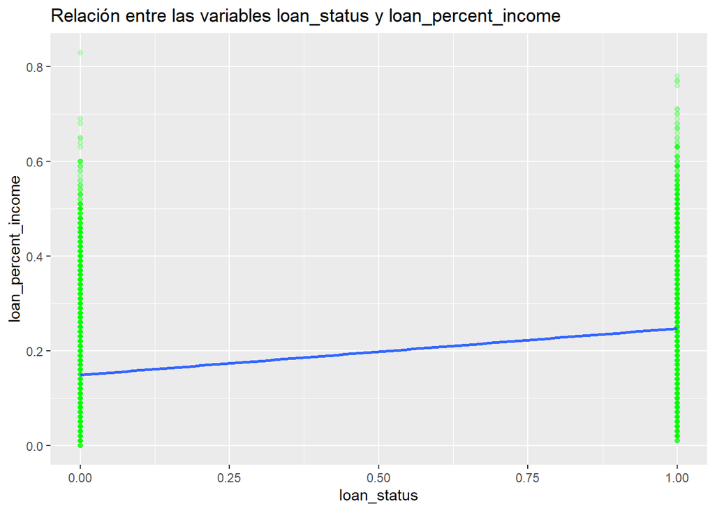

```r
fcr_train %>%
    ggplot(aes(loan_status, loan_percent_income)) + geom_point(alpha = 0.2,
    colour = "green") + geom_smooth(formula = "y ~ x", method = "lm") +
    labs(title = "Relación entre las variables loan_status y loan_percent_income",
        x = "loan_status", y = "loan_percent_income")
```

## 6.4. Análisis de las variables categóricas

Se realiza un análisis de las variables categóricas en relación con el resto de variables numéricas del dataset. Se trata de entender las características personales de los clientes de banca retail y su actividad crediticia para tratar de sacar un cierto análisis preliminar.

- **Variable cb_person_default_on_file en función de las variables loan_int_rate y loan_percent_income:**

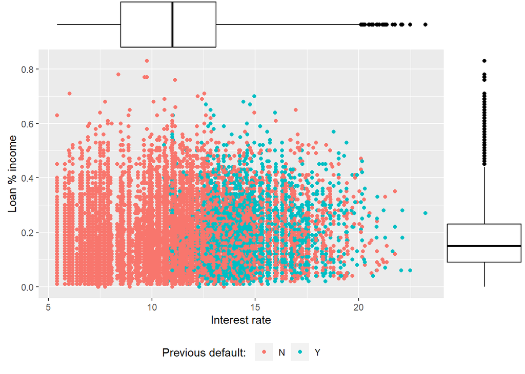

```r
plot1 <- ggplot(fcr_train, aes(loan_int_rate, loan_percent_income,
    col = cb_person_default_on_file)) + geom_point() + ylab("Loan % income") +
    xlab("Interest rate") + labs(color = "Previous default: ") +
    theme(legend.position = "bottom")

ggExtra::ggMarginal(plot1, type = "boxplot")
```

Con este gráfico se puede entender que los tipos de interés aplicados por las entidades bancarias en los préstamos que conceden, vienen influidos por si el cliente ha registrado algún impago anterior en su historial crediticio. Además, se ve como el porcentaje de lo que supone el préstamo sobre los ingresos anuales en dólares de la persona que toma el crédito, no es algo definitivo para establecer el tipo de interés que se aplica en la operación.

- **Variable person_home_ownership en función de las variables person_age y person_income:**

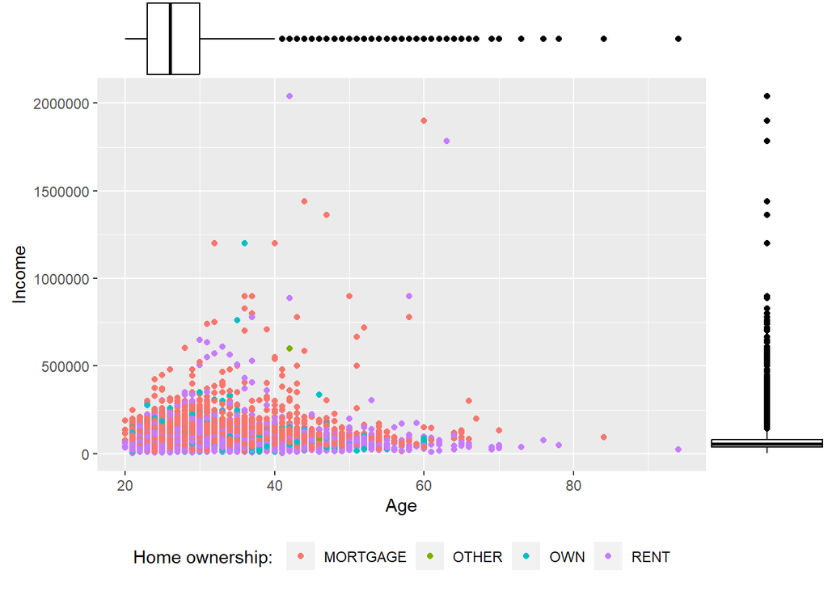

```r
plot1 <- ggplot(fcr_train, aes(person_age, person_income, col = person_home_ownership)) +
    geom_point() + ylab("Income") + xlab("Age") + labs(color = "Home ownership: ") +
    theme(legend.position = "bottom")

ggExtra::ggMarginal(plot1, type = "boxplot")
```

En base a este gráfico se puede sacar como conclusión que: existe un sesgo en la edad (el dataset tiene más registros de gente joven), existe un sesgo en los ingresos (el dataset no tiene bien balanceada la variable “person_income”, estando está desequilibrada y siendo más frecuente los ingresos bajos) y parece que la gente con hipoteca tiene por lo general más ingresos que la gente que vive de alquiler.

- **Variable loan_intent en función de las variables loan_amnt y loan_int_rate:**

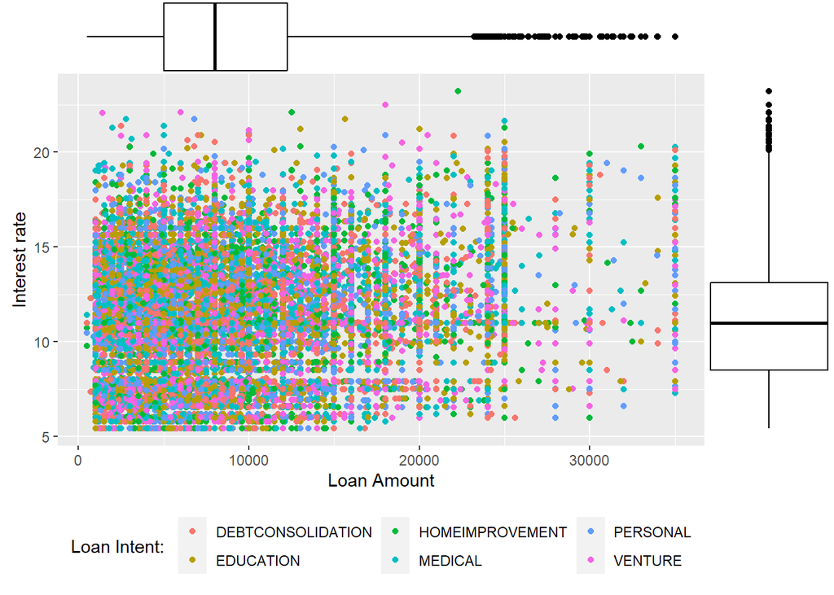

```r
plot2 <- ggplot(fcr_train, aes(loan_amnt, loan_int_rate, col = loan_intent)) +
    geom_point() + ylab("Interest rate") + xlab("Loan Amount") +
    labs(color = "Loan Intent: ") + theme(legend.position = "bottom")

ggExtra::ggMarginal(plot2, type = "boxplot")
```

Este tercer gráfico obtenido, representa la relación entre el importe del préstamo solicitado y el tipo de interés aplicado. Aquí se puede ver que no hay una correlación clara entre las dos variables, por lo que se puede decir que no dependen la una de la otra. Además, parece que la intención del préstamo se distribuye por igual en la muestra, lo que significa que la intención no influye en absoluto en los tipos de interés ni en el importe del préstamo. En este caso, las distribuciones son gaussianas normales con un ligero sesgo.

- **Variable loan_grade en función de las variables loan_amnt y person_income:**

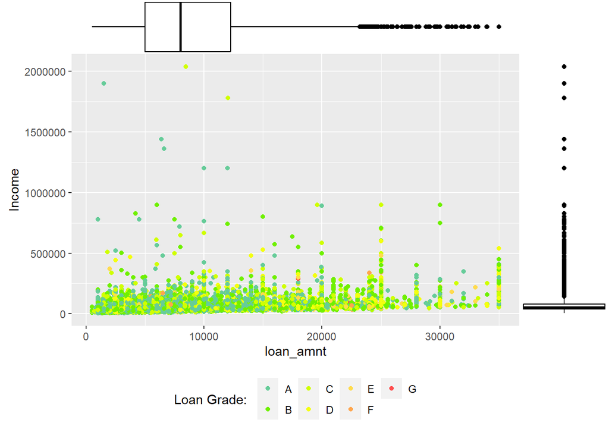

```r
plot3 <- ggplot(fcr_train, aes(loan_amnt, person_income, col = loan_grade)) +
    geom_point() + ylab("Income") + labs(color = "Loan Grade: ") +
    theme(legend.position = "bottom") + scale_color_manual(values = c("#66cc99",
    "#70F000", "#D0FF00", "#F3FF0F", "#FFDB4D", "#FFA64D", "#FF4D4D"))

ggExtra::ggMarginal(plot3, type = "boxplot")
```

En este cuarto gráfico obtenido, tampoco existe una relación clara entre los ingresos y el importe del préstamo. Al añadir diferentes colores para las calificaciones de los préstamos, se observa una pequeña tendencia a que las personas con ingresos bajos y con un préstamo elevado tengan una calificación crediticia más baja. Pero no se aprecia una relación clara.

- **Variable loan_grade en función de las variables person_age y loan_int_rate:**

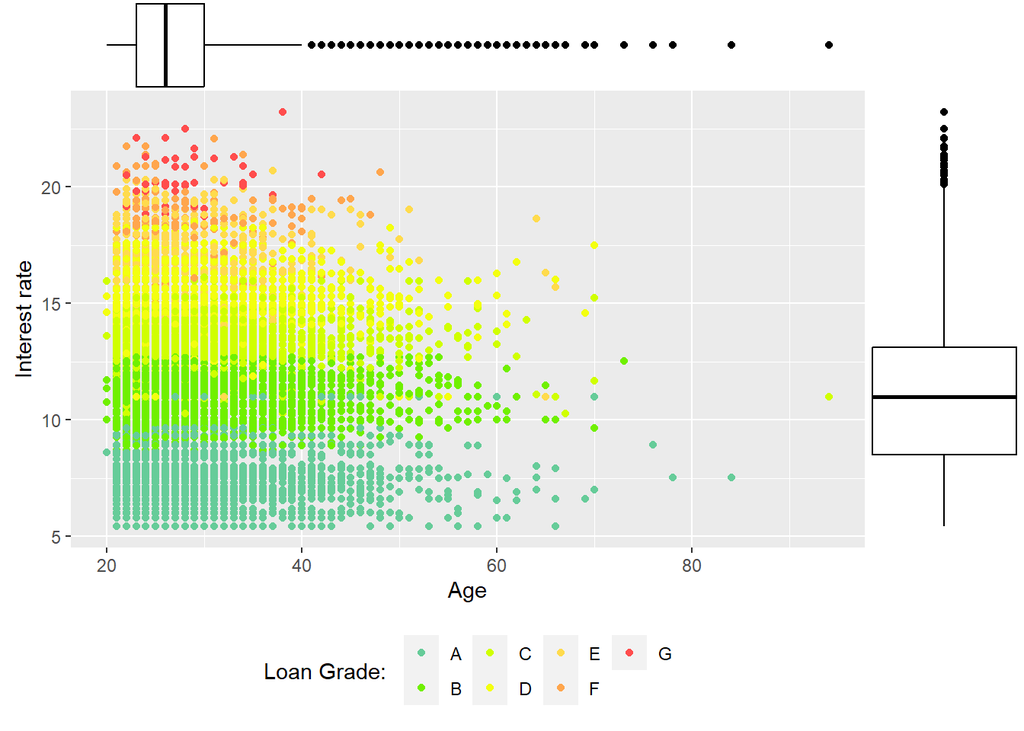

```r
plot4 <- ggplot(fcr_train, aes(person_age, loan_int_rate, col = loan_grade)) +
    geom_point() + ylab("Interest rate") + xlab("Age") + labs(color = "Loan Grade: ") +
    theme(legend.position = "bottom") + scale_color_manual(values = c("#66cc99",
    "#70F000", "#D0FF00", "#F3FF0F", "#FFDB4D", "#FFA64D", "#FF4D4D"))

ggExtra::ggMarginal(plot4, type = "boxplot")
```

En este quinto gráfico se muestra la relación entre la edad, el tipo de interés y el grado del préstamo. Aquí se puede ver claramente que la calificación del préstamo depende del tipo de interés, que divide el gráfico en varias secciones. Básicamente se puede apreciar que cuanto más alto es el tipo de interés, mayor es el riesgo percibido. Esto podría deberse al método de evaluación del grado de riesgo de las personas. Además, se observa que las personas mayores tienden a tener tipos de interés más bajos por término medio que los jóvenes.

## 6.5. Análisis de la variable de interés

Ahora se pasa a analizar la variable de interes “loan_status”, para ver la probabilidad de impago de un crédito o préstamo dadas ciertas características en el cliente o en el propio préstamos.

- **Variable loan_status en función de las variables loan_percent_income y loan_int_rate:**

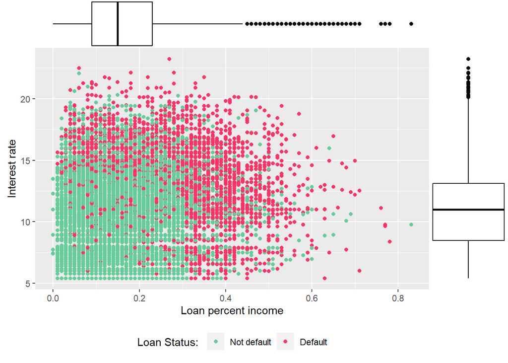

```r
plot5 <- ggplot(fcr_train, aes(loan_percent_income, loan_int_rate,
    col = factor(loan_status, labels = c("Not default", "Default")))) +
    geom_point() + ylab("Interest rate") + xlab("Loan percent income") +
    labs(color = "Loan Status: ") + theme(legend.position = "bottom") +
    scale_color_manual(values = c("#66cc99", "#ff3366"))

ggExtra::ggMarginal(plot5, type = "boxplot")
```

Si se analiza a las personas que han impagado (en rojo) y a las personas que no han impagado (en verde), podemos ver claramente niveles de umbral hacia el 12% para los tipos de interés, y 0,3 para la variable de porcentaje de lo que supone el préstamo sobre los ingresos del cliente. Esta zona podría considerarse menos arriesgada tanto para los prestamistas como para los prestatarios. Este patrón parece razonable, ya que unos tipos de interés más altos y una mayor relación ingresos/préstamo significa que es menos probable que los clientes reembolsen su deuda. Es decir, a mayor nivel de tipo de interés del préstamo y un mayor nivel de endeudamiento en relación con los ingresos, es más probable que un cliente de una entidad bancaria termine por impagar su deuda y entrar en default.

- **Variable loan_status en función de la variable person_home_ownership:**

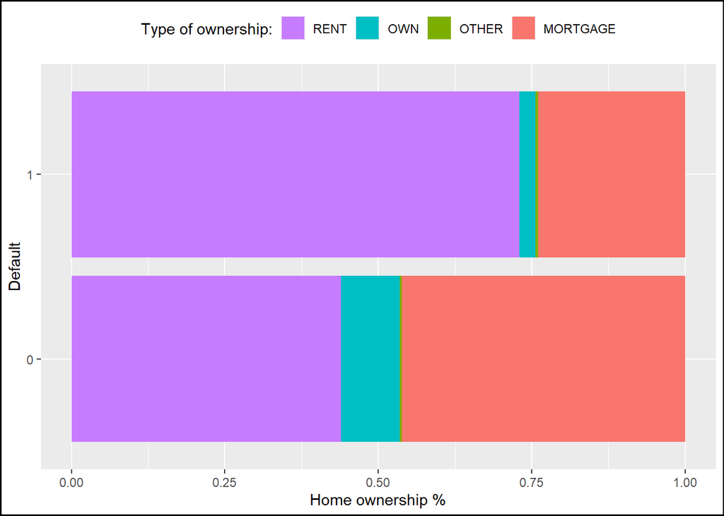

```r
ggplot(fcr_train, aes(x = factor(loan_status), fill = factor(person_home_ownership))) +
    geom_bar(position = "fill") + ylab("Home ownership %") +
    xlab("Default") + labs(fill = "Type of ownership:") + theme(legend.position = "top",
    plot.background = element_rect(colour = "black", size = 1)) +
    guides(fill = guide_legend(reverse = TRUE)) + coord_flip()
```